# lab3A

Marlee_Galloway

9/7/2020

```r
library(tidyverse)
```

```r
 download.file(url="https://ndownloader.figshare.com/files/2292169",
              destfile = "data/portal_data_joined.csv")
```

```r
surveys <- read_csv("data/portal_data_joined.csv")
surveys
```

```
## # A tibble: 34,786 x 13
##    record_id month   day  year plot_id species_id sex   hindfoot_length weight
##        <dbl> <dbl> <dbl> <dbl>   <dbl> <chr>      <chr>           <dbl>  <dbl>
##  1         1     7    16  1977       2 NL         M                  32     NA
##  2        72     8    19  1977       2 NL         M                  31     NA
##  3       224     9    13  1977       2 NL         <NA>               NA     NA
##  4       266    10    16  1977       2 NL         <NA>               NA     NA
##  5       349    11    12  1977       2 NL         <NA>               NA     NA
##  6       363    11    12  1977       2 NL         <NA>               NA     NA
##  7       435    12    10  1977       2 NL         <NA>               NA     NA
##  8       506     1     8  1978       2 NL         <NA>               NA     NA
##  9       588     2    18  1978       2 NL         M                  NA    218
## 10       661     3    11  1978       2 NL         <NA>               NA     NA
## # … with 34,776 more rows, and 4 more variables: genus <chr>, species <chr>,
## #   taxa <chr>, plot_type <chr>
```

```r
head(surveys)
```

```
## # A tibble: 6 x 13
##   record_id month   day  year plot_id species_id sex   hindfoot_length weight
##       <dbl> <dbl> <dbl> <dbl>   <dbl> <chr>      <chr>           <dbl>  <dbl>
## 1         1     7    16  1977       2 NL         M                  32     NA
## 2        72     8    19  1977       2 NL         M                  31     NA
## 3       224     9    13  1977       2 NL         <NA>               NA     NA
## 4       266    10    16  1977       2 NL         <NA>               NA     NA
## 5       349    11    12  1977       2 NL         <NA>               NA     NA
## 6       363    11    12  1977       2 NL         <NA>               NA     NA
## # … with 4 more variables: genus <chr>, species <chr>, taxa <chr>,
## #   plot_type <chr>
```

```r
str(surveys)
```

```
## tibble [34,786 × 13] (S3: spec_tbl_df/tbl_df/tbl/data.frame)
##  $ record_id      : num [1:34786] 1 72 224 266 349 363 435 506 588 661 ...
##  $ month          : num [1:34786] 7 8 9 10 11 11 12 1 2 3 ...
##  $ day            : num [1:34786] 16 19 13 16 12 12 10 8 18 11 ...
##  $ year           : num [1:34786] 1977 1977 1977 1977 1977 ...
##  $ plot_id        : num [1:34786] 2 2 2 2 2 2 2 2 2 2 ...
##  $ species_id     : chr [1:34786] "NL" "NL" "NL" "NL" ...
##  $ sex            : chr [1:34786] "M" "M" NA NA ...
##  $ hindfoot_length: num [1:34786] 32 31 NA NA NA NA NA NA NA NA ...
##  $ weight         : num [1:34786] NA NA NA NA NA NA NA NA 218 NA ...
##  $ genus          : chr [1:34786] "Neotoma" "Neotoma" "Neotoma" "Neotoma" ...
##  $ species        : chr [1:34786] "albigula" "albigula" "albigula" "albigula" ...
##  $ taxa           : chr [1:34786] "Rodent" "Rodent" "Rodent" "Rodent" ...
##  $ plot_type      : chr [1:34786] "Control" "Control" "Control" "Control" ...
##  - attr(*, "spec")=
##   .. cols(
##   ..   record_id = col_double(),
##   ..   month = col_double(),
##   ..   day = col_double(),
##   ..   year = col_double(),
##   ..   plot_id = col_double(),
##   ..   species_id = col_character(),
##   ..   sex = col_character(),
##   ..   hindfoot_length = col_double(),
##   ..   weight = col_double(),
##   ..   genus = col_character(),
##   ..   species = col_character(),
##   ..   taxa = col_character(),
##   ..   plot_type = col_character()
##   .. )
```

### Inspecting data.frame objects

#Size: #dim(surveys) - returns a vector with the number of rows in the first element, and the number of columns as the second element (the dimensions of the object) #nrow(surveys) - returns the number of rows #ncol(surveys) - returns the number of columns

#Content: #head(surveys) - shows the first 6 rows #tail(surveys) - shows the last 6 rows

#Names: #names(surveys) - returns the column names (synonym of colnames() for data.frame objects) #rownames(surveys) - returns the row names

#Summary: #str(surveys) - structure of the object and information about the class, length and content of each column #summary(surveys) - summary statistics for each column

### CHALLENGE Q1

#Based on the output of str(surveys), can you answer the following questions? #What is the class of the object surveys? #How many rows and how many columns are in this object? #How many species have been recorded during these surveys?

##Ans: ## * class: data frame ## * how many rows: 34786, how many columns: 13 ## * how many species: 48

###Indexing and Subsetting Data Frames #Extract specific data:

```r
# first element in the first column of the data frame (as a vector)
surveys[1, 1]
```

```
## # A tibble: 1 x 1
##   record_id
##       <dbl>
## 1         1
```

```r
# first element in the 6th column (as a vector)
surveys[1, 6]
```

```
## # A tibble: 1 x 1
##   species_id
##   <chr>
## 1 NL
```

```r
# first column of the data frame (as a vector)
surveys[, 1]
```

```
## # A tibble: 34,786 x 1
##    record_id
##        <dbl>
##  1         1
##  2        72
##  3       224
##  4       266
##  5       349
##  6       363
##  7       435
##  8       506
##  9       588
## 10       661
## # … with 34,776 more rows
```

```r
# first column of the data frame (as a data.frame)
surveys[1]
```

```
## # A tibble: 34,786 x 1
##    record_id
##        <dbl>
##  1         1
##  2        72
##  3       224
##  4       266
##  5       349
##  6       363
##  7       435
##  8       506
##  9       588
## 10       661
## # … with 34,776 more rows
```

```r
# first three elements in the 7th column (as a vector)
surveys[1:3, 7]
```

```
## # A tibble: 3 x 1
##   sex
##   <chr>
## 1 M
## 2 M
## 3 <NA>
```

```r
# the 3rd row of the data frame (as a data.frame)
surveys[3, ]
```

```
## # A tibble: 1 x 13
##   record_id month   day  year plot_id species_id sex   hindfoot_length weight
##       <dbl> <dbl> <dbl> <dbl>   <dbl> <chr>      <chr>           <dbl>  <dbl>
## 1       224     9    13  1977       2 NL         <NA>               NA     NA
## # … with 4 more variables: genus <chr>, species <chr>, taxa <chr>,
## #   plot_type <chr>
```

```r
# equivalent to head_surveys <- head(surveys)
head_surveys <- surveys[1:6, ]
```

```r
surveys[1:10]
```

```
## # A tibble: 34,786 x 10
##    record_id month   day  year plot_id species_id sex   hindfoot_length weight
##        <dbl> <dbl> <dbl> <dbl>   <dbl> <chr>      <chr>           <dbl>  <dbl>
##  1         1     7    16  1977       2 NL         M                  32     NA
##  2        72     8    19  1977       2 NL         M                  31     NA
##  3       224     9    13  1977       2 NL         <NA>               NA     NA
##  4       266    10    16  1977       2 NL         <NA>               NA     NA
##  5       349    11    12  1977       2 NL         <NA>               NA     NA
##  6       363    11    12  1977       2 NL         <NA>               NA     NA
##  7       435    12    10  1977       2 NL         <NA>               NA     NA
##  8       506     1     8  1978       2 NL         <NA>               NA     NA
##  9       588     2    18  1978       2 NL         M                  NA    218
## 10       661     3    11  1978       2 NL         <NA>               NA     NA
## # … with 34,776 more rows, and 1 more variable: genus <chr>
```

```r
surveys[10:1]
```

```
## # A tibble: 34,786 x 10
##    genus weight hindfoot_length sex   species_id plot_id  year   day month
##    <chr>  <dbl>           <dbl> <chr> <chr>        <dbl> <dbl> <dbl> <dbl>
##  1 Neot…     NA              32 M     NL               2  1977    16     7
##  2 Neot…     NA              31 M     NL               2  1977    19     8
##  3 Neot…     NA              NA <NA>  NL               2  1977    13     9
##  4 Neot…     NA              NA <NA>  NL               2  1977    16    10
##  5 Neot…     NA              NA <NA>  NL               2  1977    12    11
##  6 Neot…     NA              NA <NA>  NL               2  1977    12    11
##  7 Neot…     NA              NA <NA>  NL               2  1977    10    12
##  8 Neot…     NA              NA <NA>  NL               2  1978     8     1
##  9 Neot…    218              NA M     NL               2  1978    18     2
## 10 Neot…     NA              NA <NA>  NL               2  1978    11     3
## # … with 34,776 more rows, and 1 more variable: record_id <dbl>
```

#Subsetting data frames by calling their column names

```r
#surveys["species_id"]       # Result is a data.frame
#surveys[, "species_id"]     # Result is a vector
#surveys[["species_id"]]     # Result is a vector
#surveys$species_id          # Result is a vector
```

###CHALLENGE Q2 #Create a data.frame (surveys_200) containing only the data in row 200 of the surveys dataset. #Notice how nrow() gave you the number of rows in a data.frame? #*Use that number to pull out just that last row in the data frame. #*Compare that with what you see as the last row using tail() to make sure it’s meeting expectations. #*Pull out that last row using nrow() instead of the row number. #*Create a new data frame (surveys_last) from that last row. #Use nrow() to extract the row that is in the middle of the data frame. Store the content of this row in an object named surveys_middle. #Combine nrow() with the - notation above to reproduce the behavior of head(surveys), keeping just the first through 6th rows of the surveys dataset.

##Ans:

```r
## 1.
surveys_200 <- surveys[200, ]
## 2.
# Saving `n_rows` to improve readability and reduce duplication
n_rows <- nrow(surveys)
surveys_last <- surveys[n_rows, ]
## 3.
surveys_middle <- surveys[n_rows / 2, ]
## 4.
surveys_head <- surveys[-(7:n_rows), ]
```

###Factors

```r
sex <- factor(c("male", "female", "female", "male"))
```

```r
levels(sex)
```

```
## [1] "female" "male"
```

```r
nlevels(sex)
```

```
## [1] 2
```

```r
sex # current order
```

```
## [1] male   female female male
## Levels: female male
```

```r
sex <- factor(sex, levels = c("male", "female"))
sex # after re-ordering
```

```
## [1] male   female female male
## Levels: male female
```

###Converting Factors

#converting a factor to a character vector:

```r
as.character(sex)
```

```
## [1] "male"   "female" "female" "male"
```

#conversion from factor to numeric:

```r
year_fct <- factor(c(1990, 1983, 1977, 1998, 1990))
as.numeric(year_fct)               # Wrong! And there is no warning...
```

```
## [1] 3 2 1 4 3
```

```r
as.numeric(as.character(year_fct)) # Works...
```

```
## [1] 1990 1983 1977 1998 1990
```

```r
as.numeric(levels(year_fct))[year_fct]    # The recommended way.
```

```
## [1] 1990 1983 1977 1998 1990
```

###Renaming Factors ## bar plot of the number of females and males captured during the experiment:

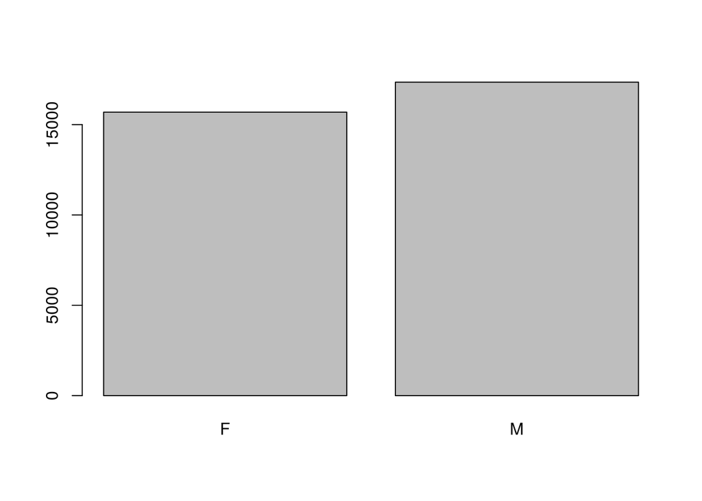

```r
plot(as.factor(surveys$sex))
```

```r
sex <- factor(surveys$sex)
head(sex)
```

```
## [1] M    M    <NA> <NA> <NA> <NA>
## Levels: F M
```

```r
levels(sex)
```

```
## [1] "F" "M"
```

```r
levels(sex)[1] <- "undetermined"
levels(sex)
```

```
## [1] "undetermined" "M"
```

```r
head(sex)
```

```
## [1] M    M    <NA> <NA> <NA> <NA>
## Levels: undetermined M
```

###CHALLENGE Q3 #Rename “F” and “M” to “female” and “male” respectively. #Now that we have renamed the factor level to “undetermined”, can you recreate the barplot such that “undetermined” is last (after “male”)?

##Ans:

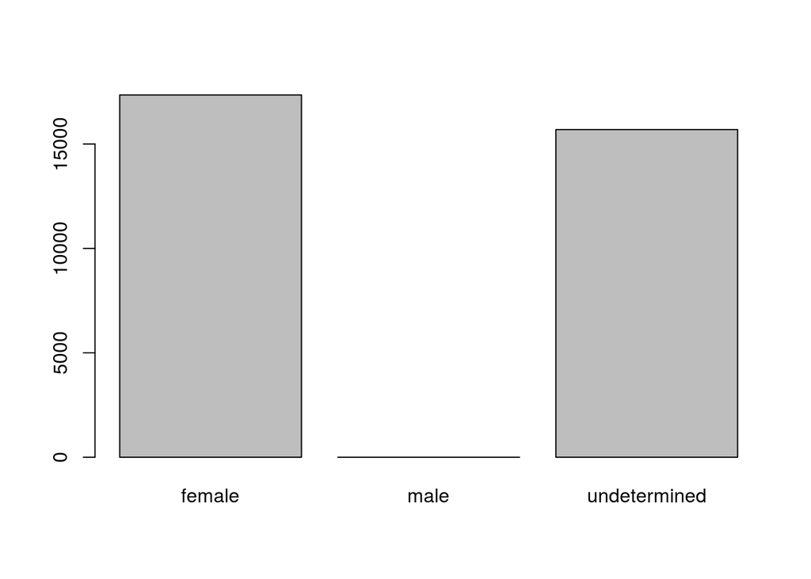

```r
levels(sex)[2:3] <- c("female", "male")
sex <- factor(sex, levels = c("female", "male", "undetermined"))
plot(sex)
```

###Using stringsAsFactors = FALSE

```r
## Compare the difference between our data read as `factor` vs `character`.
surveys <- read.csv("data/portal_data_joined.csv", stringsAsFactors = TRUE)
str(surveys)
```

```
## 'data.frame':    34786 obs. of  13 variables:
##  $ record_id      : int  1 72 224 266 349 363 435 506 588 661 ...
##  $ month          : int  7 8 9 10 11 11 12 1 2 3 ...
##  $ day            : int  16 19 13 16 12 12 10 8 18 11 ...
##  $ year           : int  1977 1977 1977 1977 1977 1977 1977 1978 1978 1978 ...
##  $ plot_id        : int  2 2 2 2 2 2 2 2 2 2 ...
##  $ species_id     : Factor w/ 48 levels "AB","AH","AS",..: 16 16 16 16 16 16 16 16 16 16 ...
##  $ sex            : Factor w/ 3 levels "","F","M": 3 3 1 1 1 1 1 1 3 1 ...
##  $ hindfoot_length: int  32 31 NA NA NA NA NA NA NA NA ...
##  $ weight         : int  NA NA NA NA NA NA NA NA 218 NA ...
##  $ genus          : Factor w/ 26 levels "Ammodramus","Ammospermophilus",..: 13 13 13 13 13 13 13 13 13 13 ...
##  $ species        : Factor w/ 40 levels "albigula","audubonii",..: 1 1 1 1 1 1 1 1 1 1 ...
##  $ taxa           : Factor w/ 4 levels "Bird","Rabbit",..: 4 4 4 4 4 4 4 4 4 4 ...
##  $ plot_type      : Factor w/ 5 levels "Control","Long-term Krat Exclosure",..: 1 1 1 1 1 1 1 1 1 1 ...
```

```r
surveys <- read.csv("data/portal_data_joined.csv", stringsAsFactors = FALSE)
str(surveys)
```

```
## 'data.frame':    34786 obs. of  13 variables:
##  $ record_id      : int  1 72 224 266 349 363 435 506 588 661 ...
##  $ month          : int  7 8 9 10 11 11 12 1 2 3 ...
##  $ day            : int  16 19 13 16 12 12 10 8 18 11 ...
##  $ year           : int  1977 1977 1977 1977 1977 1977 1977 1978 1978 1978 ...
##  $ plot_id        : int  2 2 2 2 2 2 2 2 2 2 ...
##  $ species_id     : chr  "NL" "NL" "NL" "NL" ...
##  $ sex            : chr  "M" "M" "" "" ...
##  $ hindfoot_length: int  32 31 NA NA NA NA NA NA NA NA ...
##  $ weight         : int  NA NA NA NA NA NA NA NA 218 NA ...
##  $ genus          : chr  "Neotoma" "Neotoma" "Neotoma" "Neotoma" ...
##  $ species        : chr  "albigula" "albigula" "albigula" "albigula" ...
##  $ taxa           : chr  "Rodent" "Rodent" "Rodent" "Rodent" ...
##  $ plot_type      : chr  "Control" "Control" "Control" "Control" ...
```

```r
## Convert the column "plot_type" into a factor
surveys$plot_type <- factor(surveys$plot_type)
```

###CHALLENGE Q4 #1 We have seen how data frames are created when using read.csv(), but they can also be created by hand with the data.frame() function. There are a few mistakes in this hand-crafted data.frame. Can you spot and fix them? Don’t hesitate to experiment!

#animal_data <- data.frame( # animal = c(dog, cat, sea cucumber, sea urchin), # feel = c(“furry”, “squishy”, “spiny”), # weight = c(45, 8 1.1, 0.8) # )

#2 Can you predict the class for each of the columns in the following example? Check your guesses using str(country_climate): #Are they what you expected? Why? Why not? #What would have been different if we had added stringsAsFactors = FALSE when creating the data frame? #What would you need to change to ensure that each column had the accurate data type?

#country_climate <- data.frame( # country = c(“Canada”, “Panama”, “South Africa”, “Australia”), # climate = c(“cold”, “hot”, “temperate”, “hot/temperate”), # temperature = c(10, 30, 18, “15”), # northern_hemisphere = c(TRUE, TRUE, FALSE, “FALSE”), # has_kangaroo = c(FALSE, FALSE, FALSE, 1) # )

##Ans: #missing quotations around the names of the animals #missing one entry in the feel column (probably for one of the furry animals) #missing one comma in the weight column #country, climate, temperature, and northern_hemisphere are factors; has_kangaroo is numeric #using stringsAsFactors = FALSE would have made character vectors instead of factors #removing the quotes in temperature and northern_hemisphere and replacing 1 by TRUE in the has_kangaroo column would give what was probably intended

###Formatting Dates

```r
str(surveys)
```

```
## 'data.frame':    34786 obs. of  13 variables:
##  $ record_id      : int  1 72 224 266 349 363 435 506 588 661 ...
##  $ month          : int  7 8 9 10 11 11 12 1 2 3 ...
##  $ day            : int  16 19 13 16 12 12 10 8 18 11 ...
##  $ year           : int  1977 1977 1977 1977 1977 1977 1977 1978 1978 1978 ...
##  $ plot_id        : int  2 2 2 2 2 2 2 2 2 2 ...
##  $ species_id     : chr  "NL" "NL" "NL" "NL" ...
##  $ sex            : chr  "M" "M" "" "" ...
##  $ hindfoot_length: int  32 31 NA NA NA NA NA NA NA NA ...
##  $ weight         : int  NA NA NA NA NA NA NA NA 218 NA ...
##  $ genus          : chr  "Neotoma" "Neotoma" "Neotoma" "Neotoma" ...
##  $ species        : chr  "albigula" "albigula" "albigula" "albigula" ...
##  $ taxa           : chr  "Rodent" "Rodent" "Rodent" "Rodent" ...
##  $ plot_type      : Factor w/ 5 levels "Control","Long-term Krat Exclosure",..: 1 1 1 1 1 1 1 1 1 1 ...
```

```r
library("lubridate")
my_date <- ymd("2015-01-01")
str(my_date)
```

```
##  Date[1:1], format: "2015-01-01"
```

```r
my_date <- ymd(paste("2015", "1", "1", sep = "-"))
str(my_date)
```

```
##  Date[1:1], format: "2015-01-01"
```

#paste(surveys$year, surveys$month, surveys$day, sep = "-") #ymd(paste(surveys$year, surveys$month, surveys$day, sep = “-”))

```r
surveys$date <- ymd(paste(surveys$year, surveys$month, surveys$day, sep = "-"))
str(surveys) # notice the new column, with 'date' as the class
```

```
## 'data.frame':    34786 obs. of  14 variables:
##  $ record_id      : int  1 72 224 266 349 363 435 506 588 661 ...
##  $ month          : int  7 8 9 10 11 11 12 1 2 3 ...
##  $ day            : int  16 19 13 16 12 12 10 8 18 11 ...
##  $ year           : int  1977 1977 1977 1977 1977 1977 1977 1978 1978 1978 ...
##  $ plot_id        : int  2 2 2 2 2 2 2 2 2 2 ...
##  $ species_id     : chr  "NL" "NL" "NL" "NL" ...
##  $ sex            : chr  "M" "M" "" "" ...
##  $ hindfoot_length: int  32 31 NA NA NA NA NA NA NA NA ...
##  $ weight         : int  NA NA NA NA NA NA NA NA 218 NA ...
##  $ genus          : chr  "Neotoma" "Neotoma" "Neotoma" "Neotoma" ...
##  $ species        : chr  "albigula" "albigula" "albigula" "albigula" ...
##  $ taxa           : chr  "Rodent" "Rodent" "Rodent" "Rodent" ...
##  $ plot_type      : Factor w/ 5 levels "Control","Long-term Krat Exclosure",..: 1 1 1 1 1 1 1 1 1 1 ...
##  $ date           : Date, format: "1977-07-16" "1977-08-19" ...
```

```r
summary(surveys$date)
```

```
##         Min.      1st Qu.       Median         Mean      3rd Qu.         Max.
## "1977-07-16" "1984-03-12" "1990-07-22" "1990-12-15" "1997-07-29" "2002-12-31"
##         NA's
##        "129"
```

```r
missing_dates <- surveys[is.na(surveys$date), c("year", "month", "day")]

head(missing_dates)
```

```
##      year month day
## 3144 2000     9  31
## 3817 2000     4  31
## 3818 2000     4  31
## 3819 2000     4  31
## 3820 2000     4  31
## 3856 2000     9  31
```